# R中portfolio包的比较

蓝海

R中比较常见的资产优化组合相关的包有fPortfolio, parma 和 portfolioanalytics。 下边我们通过几个例子来看看它们各自的特性，以及存在的问题。 我们考虑资产组合中比较基本的三个问题：

- 给定风险，计算期望收益最大的组合
- 给定期望收益，计算风险最小组合
- 计算市场有效边际。

具体算例为

- 三资产模型
- 参数为： $\mu_1=\mu_2=8\%$,$\mu_3=5\%$,$\sigma_1=20\%$,$\sigma_2=21\%$,$\sigma_3=10\%$ and $\rho_{i,j}=80\%,i\neq j$
- 问题：
- Q1：给定风险$\sigma_p=15\%$，寻找期望收益最大组合。
- Q2：给定收益$r_p=7\%$，寻找风险最小的组合。
- Q3：计算市场有效边际。

任何一个资产优化组合包都应该提供以上三个基本的功能，除此之外，应该考虑对更实际、更复杂问题的支持或者拓展的可能。

# fPortfolio

安装命令

```r
install.packages('fPortfolio')
```

## 测算Q1（可以做空）

问题简单，接口的调用也很简洁。唯一需要注意的是大多数组合优化包在设计时都是从输入投资回报的原始数据开始的。对于我们这样直接给出期望收益和方差的问题，反而需要产生一些伪回报的随机数，以满足函数借口的调用检查。

```r
require('fPortfolio')
my_mean_var_setting<-function(x,spec)
{
  mu<-c(0.08,0.08,0.05)
  names(mu)<-c('A1','A2','A3')
  Sigma<-matrix(0.8,3,3)
  Sigma[1,1]<-1
  Sigma[2,2]<-1
  Sigma[3,3]<-1
  var<-c(0.2,0.21,0.1)
  Sigma<-t(var*Sigma)*var
  list(mu=mu,Sigma=Sigma)
}
setting<-my_mean_var_setting(NULL,NULL)
mySpec <-portfolioSpec()
setTargetRisk(mySpec)<-0.15
setSolver(mySpec)<-'solveRshortExact'
port<-maxreturnPortfolio(setting,mySpec,constraints = 'Short')
print(port)
```

```
Title:
 MV Return Maximized Efficient Portfolio
 Estimator:         covEstimator
 Solver:            solveRshortExact
 Optimize:          maxReturn
 Constraints:       Short

Portfolio Weights:
    A1     A2     A3
0.3833 0.2020 0.4147

Covariance Risk Budgets:
    A1     A2     A3
0.4898 0.2582 0.2520

Target Return and Risk:
[1] 0.0676

Description:
 Sun May 14 19:01:09 2017 by user:
```

这可能是完成Q1问题最为简洁的代码。

可是fPortfolio的设计者在构建该软件包的时候，是试图从时序数据开始处理的。对于这样简单的直接给出期望回报和方差的例子在计算的时候反而问题很多。大多数问题都是涉及数据封装。尽管从理论上模型只需要依赖于给出的期望回报和方差，可是在实际的程序中，尤其是一些独立的优化方法调用以及风险度量的模块里头不太合理的访问了原始的时序数据，从而形成了封装不严谨的问题。比如我们的例子中对于期望收益和风险的计算就是不正确的。

```r
require('fPortfolio')
require('Rsocp')
require('MASS')

my_mean_var_setting<-function(x,spec)
{
  mu<-c(0.08,0.08,0.05)
  names(mu)<-c('A1','A2','A3')
  Sigma<-matrix(0.8,3,3)
  Sigma[1,1]<-1
  Sigma[2,2]<-1
  Sigma[3,3]<-1
  var<-c(0.2,0.21,0.1)
  Sigma<-t(var*Sigma)*var
  list(mu=mu,Sigma=Sigma)
}
setting<-my_mean_var_setting(NULL,NULL)
faked_data<-mvrnorm(100, setting$mu, setting$Sigma)
colnames(faked_data)<-c('A1','A2','A3')
mySpec <-portfolioSpec()
setTargetRisk(mySpec)<-0.15
setSolver(mySpec)<-'solveRsocp'
setEstimator(mySpec)<-'my_mean_var_setting'
myData<-portfolioData(as.timeSeries(faked_data),mySpec)
port<-maxreturnPortfolio(myData,mySpec,constraints = 'Short')
print(port)
```

尽管我们为了使用fportfolio而人为生成了伪时序数据，但是奇怪的是后续在Rsocp包中又试图将作者自定义的类timeSeries转化为R原生数据类型vector从而估计出一个合理的缩放比例进行数值计算的精度控制。这是典型的不合理使用数据封装的例子，达成同样的目的，其实可以使用Sigma数据中的最大数。

R包Rsocp是老式c程序包socp的R接口拓展。该程序解决如下问题。
$$\begin{aligned}
&\min f^t x \\
s.t. & ||A_i^tx + b_i||=c_i^t x + d_i
\end{aligned}$$
对应的接口函数.rsocpArguments处理参数的转换与准备问题。我们可以使用如下方式

```r
debug(maxreturnPortfolio)
```

查看具体问题出现的地方。发现在函数.rsocpArguments中出现一处问题：访问eqsumW[2, -1]用以生成约束$\sum w_i =1$。这种硬访问的方式很容易出现前后处理不一致的情况。果然在准备eqsumW的函数中，原本设计的函数是针对最小方差的问题设计。因此在eqsumW中第一行是表述目标收益的约束，第二行是进行资产权重的约束，比如全部投资约束则要求总权重为1。而在最大收益的模型中，第一项目的约束是不存在的。这里有两种可以的处理方法：一是保持一个约束存在，目标值为NA，我们在.rsocpArguments中只是访问第二行。如果这样处理的话，我们需要在准备的eqsumW的函数中保留那些包含NA的约束，而系统似乎有意的以NA作为自由变量的约束表达方式。所以我们决定不采用这种方式，还是在.rsocpArguments函数中，将eqsumW[2, -1]改为eqsumW[1, -1]。验证的时候可以用

```r
trace('.rsocpArguments',edit=T)
```

进行修改验证，只是需要注意这种修改不是永久的。验证通过后，我们需要通过下载fPortfolio的源文件，修改后重新安装本地版本的包。下载地址https://cloud.r-project.org/。具体步骤为：

```r
require('fPortfolio')
require('Rsocp')
require('MASS')
my_mean_var_setting<-function(x,spec)
{
  mu<-c(0.08,0.08,0.05)
  names(mu)<-c('A1','A2','A3')
  Sigma<-matrix(0.8,3,3)
  Sigma[1,1]<-1
  Sigma[2,2]<-1
  Sigma[3,3]<-1
  var<-c(0.2,0.21,0.1)
  Sigma<-t(var*Sigma)*var
  list(mu=mu,Sigma=Sigma)
}
setting<-my_mean_var_setting(NULL,NULL)
faked_data<-mvrnorm(100, setting$mu, setting$Sigma)
colnames(faked_data)<-c('A1','A2','A3')
mySpec <-portfolioSpec()
setTargetRisk(mySpec)<-0.15
setSolver(mySpec)<-'solveRsocp'
setEstimator(mySpec)<-'my_mean_var_setting'
myData<-portfolioData(as.timeSeries(faked_data),mySpec)
port<-maxreturnPortfolio(myData,mySpec,constraints = 'Short')
print(port)
```

```
Title:
 MV Return Maximized Efficient Portfolio
 Estimator:         my_mean_var_setting
 Solver:            solveRsocp
 Optimize:          maxReturn
 Constraints:       Short

Portfolio Weights:
    A1     A2     A3
0.3833 0.2020 0.4147

Covariance Risk Budgets:
    A1     A2     A3
0.4943 0.2433 0.2624

Target Returns and Risks:
  mean     mu    Cov  Sigma   CVaR    VaR
0.0777 0.0676 0.1467 0.1500 0.1884 0.1574

Description:
 Sun May 14 11:20:49 2017 by user:
```

重复运行之前不能正常运行的代码，在我们修改错误后得到如上的结果。

## 测算Q2（可以做空）

对于可以做空的情况，因为在理论上存在close-form的解，所以使用solveRshortExact作为solver是最为高效的做饭。同时需要注意虽然在理论上使用solveRquadprog也应该能够求解，但是由于接口设计的欠缺，实际上是不能使用的。

```r
require('fPortfolio')
my_mean_var_setting<-function(x,spec)
{
  mu<-c(0.08,0.08,0.05)
  names(mu)<-c('A1','A2','A3')
  Sigma<-matrix(0.8,3,3)
  Sigma[1,1]<-1
  Sigma[2,2]<-1
  Sigma[3,3]<-1
  var<-c(0.2,0.21,0.1)
  Sigma<-t(var*Sigma)*var
  list(mu=mu,Sigma=Sigma)
}
setting<-my_mean_var_setting(NULL,NULL)
mySpec <-portfolioSpec()
setTargetReturn(mySpec)<-0.07
setSolver(mySpec)<-'solveRshortExact'
port<-efficientPortfolio(setting,mySpec,constraints = 'Short')
print(port)
```

```
Title:
 MV Efficient Portfolio
 Estimator:         covEstimator
 Solver:            solveRshortExact
 Optimize:          minRisk
 Constraints:       Short

Portfolio Weights:
    A1     A2     A3
0.4300 0.2367 0.3333

Covariance Risk Budgets:
    A1     A2     A3
0.5232 0.2880 0.1888

Target Return and Risk:
[1] 0.07

Description:
 Sun May 14 21:49:21 2017 by user:
```

## 测算Q2（不许做空）

```r
require('fPortfolio')
my_mean_var_setting<-function(x,spec)
{
  mu<-c(0.08,0.08,0.05)
  names(mu)<-c('A1','A2','A3')
  Sigma<-matrix(0.8,3,3)
  Sigma[1,1]<-1
  Sigma[2,2]<-1
  Sigma[3,3]<-1
  var<-c(0.2,0.21,0.1)
  Sigma<-t(var*Sigma)*var
  list(mu=mu,Sigma=Sigma)
}
setting<-my_mean_var_setting(NULL,NULL)
mySpec <-portfolioSpec()
setTargetReturn(mySpec)<-0.07
setSolver(mySpec)<-'solveRquadprog'
port<-efficientPortfolio(setting,mySpec,constraints = 'LongOnly')
print(port)
```

## 测算Q3（可以做空）

```r
require('MASS')
require('fPortfolio')
my_mean_var_setting<-function(x,spec)
{
  mu<-c(0.08,0.08,0.05)
  names(mu)<-c('A1','A2','A3')
  Sigma<-matrix(0.8,3,3)
  Sigma[1,1]<-1
  Sigma[2,2]<-1
  Sigma[3,3]<-1
  var<-c(0.2,0.21,0.1)
  Sigma<-t(var*Sigma)*var
  list(mu=mu,Sigma=Sigma)
}
setting<-my_mean_var_setting(NULL,NULL)
faked_data<-mvrnorm(100, setting$mu, setting$Sigma)
colnames(faked_data)<-c('A1','A2','A3')
mySpec <-portfolioSpec()
setNFrontierPoints(mySpec)<-100
setEstimator(mySpec)<-'my_mean_var_setting'
setSolver(mySpec)<-'solveRshortExact'
myData<-portfolioData(as.timeSeries(faked_data),mySpec)
shortFrontier<-portfolioFrontier(myData,mySpec,constraints = "Short")
tailoredFrontierPlot(shortFrontier,return='mu',risk='Sigma',mText='MP Portfolio - Shorting Allowed')
```

[output not shown]

## 测算Q3（不许做空）

```r
require('MASS')
require('fPortfolio')
my_mean_var_setting<-function(x,spec)
{
  mu<-c(0.08,0.08,0.05)
  names(mu)<-c('A1','A2','A3')
  Sigma<-matrix(0.8,3,3)
  Sigma[1,1]<-1
  Sigma[2,2]<-1
  Sigma[3,3]<-1
  var<-c(0.2,0.21,0.1)
  Sigma<-t(var*Sigma)*var
  list(mu=mu,Sigma=Sigma)
}
setting<-my_mean_var_setting(NULL,NULL)
faked_data<-mvrnorm(100, setting$mu, setting$Sigma)
colnames(faked_data)<-c('A1','A2','A3')
mySpec <-portfolioSpec()
setNFrontierPoints(mySpec)<-100
setEstimator(mySpec)<-'my_mean_var_setting'
myData<-portfolioData(as.timeSeries(faked_data),mySpec)
longFrontier<-portfolioFrontier(myData,mySpec,constraints = "LongOnly")
tailoredFrontierPlot(longFrontier,return='mu',risk='Sigma',mText='MP Portfolio - Long Only')
```

[output not shown]

## 关于fPortfolio的总结

这是一个比较广泛使用投资组合包，其特点是

- 接口简单
- 包括线性、整数、二次规划等确定性算法，可以基于Var, CVaR等计算
- 不包括随机算法，因而对于非凸规划问题没有现成的solver
- 包括了丰富的基于历史数据的参数估计方法，流行的管制方法等
- 对投资组合有回测功能
- 扩展容易

其缺点是

- 因为要包含太多的solver使得接口设计混乱，封装失败，从而错误极多。建议使用熟悉的套路或者先验证后再使用不熟悉的功能

# Parma

安装命令

```r
install.packages('parma')
```

## 测算Q1（可以做空）

因为对应问题的描述，都统一的封装在parmaspec的生成函数中，所以该函数的调用十分复杂。通过

```r
args(parmaspec)
```

我们可以看到函数的具体接口。 详细一些的帮助，可以通过一下命令查看。

```r
help(parmaspec)
```

相对于fPortfolio改进的地方是，在问题描述成功生成后，能够使用什么样的solver来解决问题，可以通过show(mySpec)来查看。比如我们这里就只能够使用SOCP来计算。

```r
require('parma')
my_mean_var_setting<-function(x,spec)
{
  mu<-c(0.08,0.08,0.05)
  names(mu)<-c('A1','A2','A3')
  Sigma<-matrix(0.8,3,3)
  Sigma[1,1]<-1
  Sigma[2,2]<-1
  Sigma[3,3]<-1
  var<-c(0.2,0.21,0.1)
  Sigma<-t(var*Sigma)*var
  list(mu=mu,Sigma=Sigma)
}
setting <- my_mean_var_setting()
mySpec<-parmaspec(S=setting$Sigma,forecast = setting$mu, risk='EV',riskType = 'maxreward',riskB=0.15,asset.names=names(setting$mu))
#show(mySpec)
sol = parmasolve(mySpec,type='SOCP')
weights(sol)
```

```
       A1        A2        A3
0.3832635 0.2020196 0.4147269
```

```r
parmarisk(sol)
```

```
    EV
0.0225
```

```r
parmareward(sol)
```

```
[1] 0.06755899
```

注意此处risk的描述用的是EV——方差，而我们通常设定的是均方差15%。因而计算控制的EV为其平方2.25%。

## 测算Q1（不许做空）

```r
require('parma')
my_mean_var_setting<-function(x,spec)
{
  mu<-c(0.08,0.08,0.05)
  names(mu)<-c('A1','A2','A3')
  Sigma<-matrix(0.8,3,3)
  Sigma[1,1]<-1
  Sigma[2,2]<-1
  Sigma[3,3]<-1
  var<-c(0.2,0.21,0.1)
  Sigma<-t(var*Sigma)*var
  list(mu=mu,Sigma=Sigma)
}
setting <- my_mean_var_setting()
mySpec<-parmaspec(S=setting$Sigma,forecast = setting$mu, risk='EV',riskType = 'maxreward',riskB=0.15,asset.names=names(setting$mu),LB=rep(0,3))
#show(mySpec)
sol = parmasolve(mySpec,type='SOCP')
weights(sol)
```

```
       A1        A2        A3
0.3832635 0.2020196 0.4147269
```

```r
parmarisk(sol)
```

```
    EV
0.0225
```

```r
parmareward(sol)
```

```
[1] 0.06755899
```

## 测算Q2 （可以做空）

```r
require('parma')
my_mean_var_setting<-function(x,spec)
{
  mu<-c(0.08,0.08,0.05)
  names(mu)<-c('A1','A2','A3')
  Sigma<-matrix(0.8,3,3)
  Sigma[1,1]<-1
  Sigma[2,2]<-1
  Sigma[3,3]<-1
  var<-c(0.2,0.21,0.1)
  Sigma<-t(var*Sigma)*var
  list(mu=mu,Sigma=Sigma)
}
setting <- my_mean_var_setting()
mySpec<-parmaspec(S=setting$Sigma,forecast = setting$mu, risk='EV',riskType = 'minrisk',target=0.07,targetType='equality',asset.names=names(setting$mu))
show(mySpec)
```

```
+---------------------------------+
|       PARMA Specification       |
+---------------------------------+
No.Assets       : 3
Problem         : QP,SOCP
Input           : Covariance
Risk Measure    : EV
Objective       : minrisk
```

```r
sol_socp = parmasolve(mySpec,type='SOCP')
weights(sol_socp)
```

```
       A1        A2        A3
0.4298733 0.2367533 0.3333833
```

```r
parmarisk(sol_socp)
```

```
        EV
0.02505223
```

```r
parmareward(sol_socp)
```

```
[1] 0.0699993
```

```r
sol_qp = parmasolve(mySpec,type='QP')
weights(sol_qp)
```

```
       A1        A2        A3
0.4299803 0.2366864 0.3333333
```

```r
parmarisk(sol_qp)
```

```
        EV
0.02505325
```

```r
parmareward(sol_qp)
```

```
[1] 0.07
```

## 测算Q2 （不许做空）

```r
require('parma')
my_mean_var_setting<-function(x,spec)
{
  mu<-c(0.08,0.08,0.05)
  names(mu)<-c('A1','A2','A3')
  Sigma<-matrix(0.8,3,3)
  Sigma[1,1]<-1
  Sigma[2,2]<-1
  Sigma[3,3]<-1
  var<-c(0.2,0.21,0.1)
  Sigma<-t(var*Sigma)*var
  list(mu=mu,Sigma=Sigma)
}
setting <- my_mean_var_setting()
mySpec<-parmaspec(S=setting$Sigma,forecast = setting$mu, risk='EV',riskType = 'minrisk',target=0.07,targetType='equality',asset.names=names(setting$mu),LB=rep(0,3))
show(mySpec)
sol_socp = parmasolve(mySpec,type='SOCP')
weights(sol_socp)
parmarisk(sol_socp)
parmareward(sol_socp)
sol_qp = parmasolve(mySpec,type='QP')
weights(sol_qp)
parmarisk(sol_qp)
parmareward(sol_qp)
```

## 测算Q3 （可以做空）

parma包的一个好处是可以方便的使用并行计算。此处我们使用parallel包利用普遍存在的多核心CPU加快计算。

```r
require('parallel')
require('parma')
cl = makeForkCluster(16)
mySpec<-parmaspec(S=setting$Sigma,forecast = setting$mu, risk='EV',riskType = 'minrisk',target=0.0,targetType='equality',asset.names=names(setting$mu))
front_qp = parmafrontier(mySpec,n.points = 100,type='QP',cluster=cl)
show(front_qp)
```

```
                 A1           A2            A3         EV     reward
  [1,] 2.012279e-16 0.000000e+00  1.000000e+00 0.01000000 0.05000000
  [2,] 1.010101e-02 1.203653e-18  9.898990e-01 0.01012305 0.05030303
  [3,] 2.020202e-02 2.407306e-18  9.797980e-01 0.01024977 0.05060606
  [4,] 3.030303e-02 3.610959e-18  9.696970e-01 0.01038017 0.05090909
  [5,] 4.040404e-02 4.814612e-18  9.595960e-01 0.01051423 0.05121212
  [6,] 5.050505e-02 6.018265e-18  9.494949e-01 0.01065197 0.05151515
  [7,] 6.060606e-02 7.221918e-18  9.393939e-01 0.01079339 0.05181818
  [8,] 7.070707e-02 8.425570e-18  9.292929e-01 0.01093848 0.05212121
  [9,] 8.080808e-02 9.629223e-18  9.191919e-01 0.01108724 0.05242424
 [10,] 9.090909e-02 1.083288e-17  9.090909e-01 0.01123967 0.05272727
 [11,] 1.010101e-01 1.203653e-17  8.989899e-01 0.01139578 0.05303030
 [12,] 1.111111e-01 2.103212e-16  8.888889e-01 0.01155556 0.05333333
 [13,] 1.169087e-01 4.303389e-03  8.787879e-01 0.01171870 0.05363636
 [14,] 1.227064e-01 8.606778e-03  8.686869e-01 0.01188488 0.05393939
```

[output cut: 86 more lines]

我们可以进一步的绘画出市场的最有边界来。

```r
r1=sqrt(front_qp[,'EV'])
rw1=front_qp[,'reward']
mySpec2<-parmaspec(S=setting$Sigma,forecast = setting$mu, risk='EV',riskType = 'optimal',target=0.0,targetType='equality',asset.names=names(setting$mu))
show(mySpec2)
```

```
+---------------------------------+
|       PARMA Specification       |
+---------------------------------+
No.Assets       : 3
Problem         : QP,SOCP
Input           : Covariance
Risk Measure    : EV
Objective       : optimal
```

```r
opt_qp=parmasolve(mySpec2,type='QP')
show(opt_qp)
```

```
+---------------------------------+
|        PARMA Portfolio          |
+---------------------------------+
No.Assets       : 3
Problem         : QP
Risk Measure    : EV
Objective       : optimal
Risk            : 0.01
Reward          : 0.05

   Optimal_Weights
A3               1
```

```r
plot(r1, rw1, type = 'p', col = 'steelblue', xlab = 'STD', ylab = 'Mean',
    main = 'Mean-STD Frontier')
points(parmarisk(opt_lp), parmareward(opt_lp), col = 'yellow', pch = 6, lwd = 3)
```

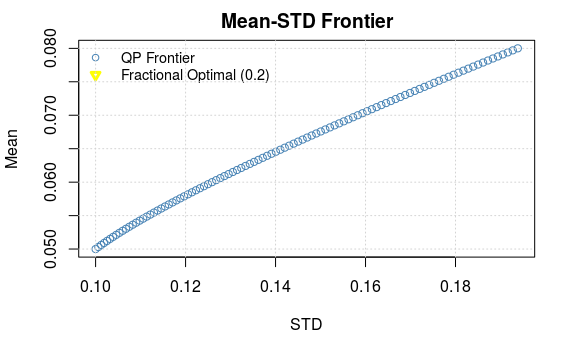

```r
legend('topleft', c('QP Frontier',  paste('Fractional Optimal (',
    round(parmarisk(opt_qp)/parmareward(opt_qp), 3), ')', sep = '')), col = c('steelblue', 'yellow'), pch = c(1, 6), lwd = c(1, 3),
    lty = c(0,  0), bty = 'n', cex = 0.9)
grid()
```

不许做空的情形相似，在此不在列出。

## parma总结

作为一个资产配置的计算包，parma相对于之前的fPortfolio要友好很多。其主要特点是

- 逻辑结构简单，提示信息丰富
- 支持算法丰富
- 网站http://unstarched.net/r-examples/parma/custom-constraints/提供了很好的使用说明，并且有很多给予parma的实用的例子

缺点是

- 接口参数多，参数设置复杂
- 不支持投资组合回测
- 没有封装市场有效边界的绘画

# PortfolioAnalytics

这个包是我测试的3个包中帮助文档最为全面的。在此我们显示一下，如何实用R自带的帮助系统来学习一个新的包的功能。在安装和载入包完成之后，我们使用如下命令可以得到关于包的一个初步介绍。

```r
require('PortfolioAnalytics')
help('PortfolioAnalytics')
```

成熟的R包，往往除了参考文档之外，还会提供若干个vignette，它们描述了场景化的应用，往往比参考文档更有说明力。

```r
vignette(all=F)
vignette('portfolio_vignette')
```

参照该文档我们可以进行针对PortfolioAnalytics的测试。但是，我们不得不加一句评论，PortfolioAnalytics包与RPortfolio包类似，其设计初衷是面向历史回报数据的。我们此处采用的教学用的“玩具”问题，在求解上反而繁琐不少。

## 测试Q1

```r
require('MASS')
require('PortfolioAnalytics')
require('xts')

mySpec<-portfolio.spec(assets=c('A1','A2','A3'))
mySpec<-add.constraint(portfolio=mySpec,type='weight_sum',min_sum=1,max_sum=1)
mySpec<-add.objective(portfolio = mySpec,type='return',name='mean')
mySpec<-add.objective(portfolio = mySpec,type='risk',name='StdDev',target=0.15)
my_mean_var_setting<-function(x,spec)
{
  mu<-c(0.08,0.08,0.05)
  names(mu)<-c('A1','A2','A3')
  Sigma<-matrix(0.8,3,3)
  Sigma[1,1]<-1
  Sigma[2,2]<-1
  Sigma[3,3]<-1
  var<-c(0.2,0.21,0.1)
  Sigma<-t(var*Sigma)*var
  list(mu=mu,sigma=Sigma,m3=0,m4=0)
}
setting<-my_mean_var_setting(NULL,NULL)
faked_data<-mvrnorm(100, setting$mu, setting$sigma)
colnames(faked_data)<-c('A1','A2','A3')
faked_data<-ts(faked_data,start=c(2011,1),frequency=12)
rp<-random_portfolios(mySpec,10000,rp_method = 'simplex')
opt<-optimize.portfolio(faked_data,mySpec,optimize_method = 'random',rp=rp,trace=T)
```

尽管程序已经足够复杂，实际上任然没有能够解决我们的问题，而且即便是能够解决，随机算法得到的结果也不是理想的。所以可以说对于Q1类玩具问题，PortfolioAnalytics是无能为力的。

## 测试Q2

```r
require('MASS')
require('PortfolioAnalytics')
require('ROI')
require('foreach')
require('iterators')
require('ROI.plugin.quadprog')
require('ROI.plugin.glpk')

mySpec<-portfolio.spec(assets=c('A1','A2','A3'))
mySpec<-add.constraint(portfolio=mySpec,type='weight_sum',min_sum=1,max_sum=1)
mySpec<-add.constraint(portfolio=mySpec,type='return',return_target=0.07)
mySpec<-add.objective(portfolio = mySpec,type='risk',name='var')
my_mean_var_setting<-function(R)
{
  mu<-c(0.08,0.08,0.05)
  names(mu)<-c('A1','A2','A3')
  Sigma<-matrix(0.8,3,3)
  Sigma[1,1]<-1
  Sigma[2,2]<-1
  Sigma[3,3]<-1
  var<-c(0.2,0.21,0.1)
  Sigma<-t(var*Sigma)*var
  list(mu=mu,sigma=Sigma,m3=0,m4=0)
}
setting<-my_mean_var_setting(NULL)
faked_data<-mvrnorm(100, setting$mu, setting$sigma)
colnames(faked_data)<-c('A1','A2','A3')
faked_data<-ts(faked_data,start=c(2011,1),frequency=12)

opt<-optimize.portfolio(faked_data,mySpec,optimize_method = 'ROI',monentFUN='my_mean_var_setting')
print(opt)
```

# 总结

我并没有完全完成这次的测试，因为发现PortfolioAnalytics实际上不是为了解决这样的“玩具”问题而设计的，强制的使用它解决这样的问题费事而无聊。综合计算能力，接口设计和扩展性。我觉得parma是一个不错的选择。RPortfolio需要慎重使用。而parma和PortfolioAnalytics则是面向科研和实际的生产力工具。后者则更是具备了回测的能力。parma不具备回测能力，需要结合R中做交易回测的包blotter来工作。